# Lecture 7 - Social Neuroscience: Reading faces and bodies

The Social Brain: Critical Perspectives on Science, Society and Neurodiversity

Richard Ramsey

## Today

Part 1

- Social Neuroscience: Reading faces and bodies

Part 2

- Read articles and discuss

[figure not shown]

[figure not shown]

[figure not shown]

# Reading faces and bodies

For an overview, See Chapter 5 from Ward (2022)

## Overview

- Recap “Social Brain” circuits
- Perceiving faces
- Perceiving bodies
- Joint attention
- Trait inferences from faces and bodies

# Recap social brain circuits

## Social brain circuits

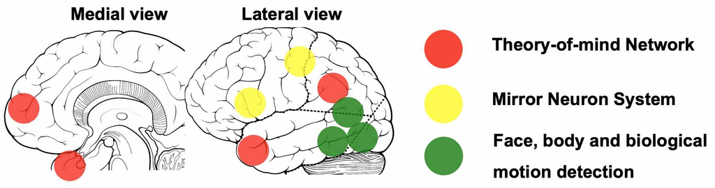

(Adolphs, 2009; Stanley & Adolphs, 2013)

# Perceiving faces

## Faces

[figure not shown]

## A cognitive model

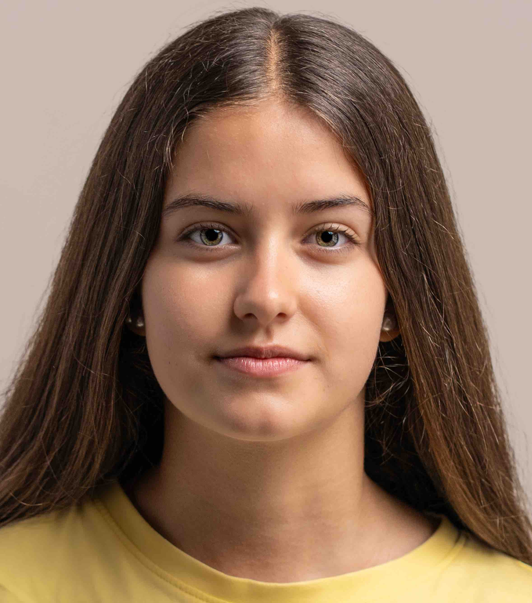

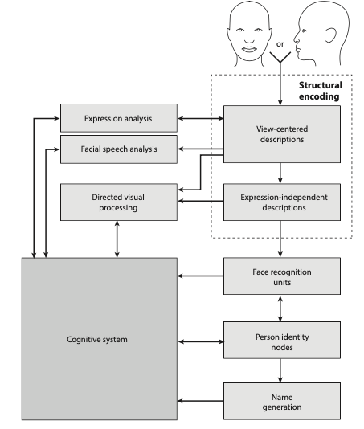

(Bruce & Young, 1986; Duchaine & Yovel, 2015)

## Neural basis of face perception

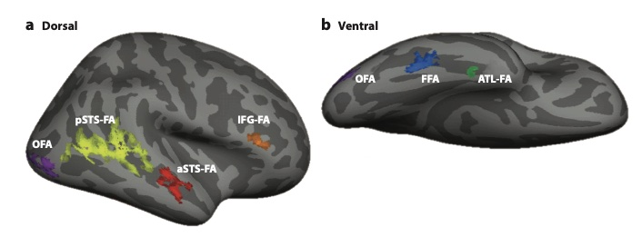

(Duchaine & Yovel, 2015)

## Core and extended systems

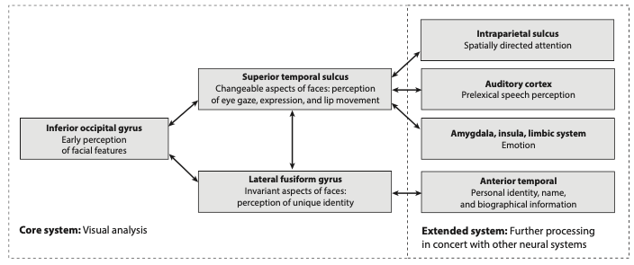

(Duchaine & Yovel, 2015; Haxby et al., 2000)

# Perceiving bodies

## Bodies

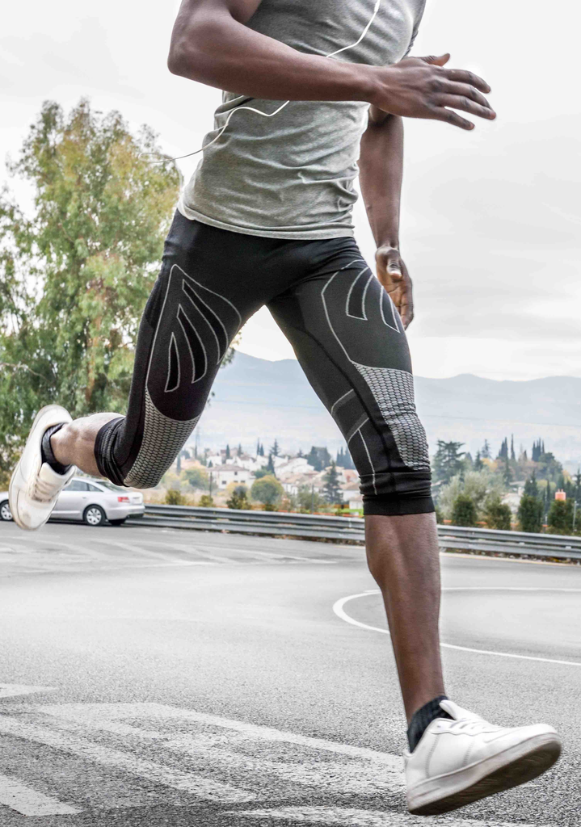

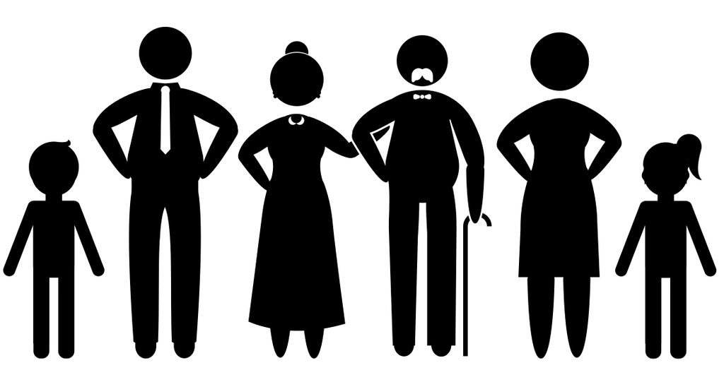

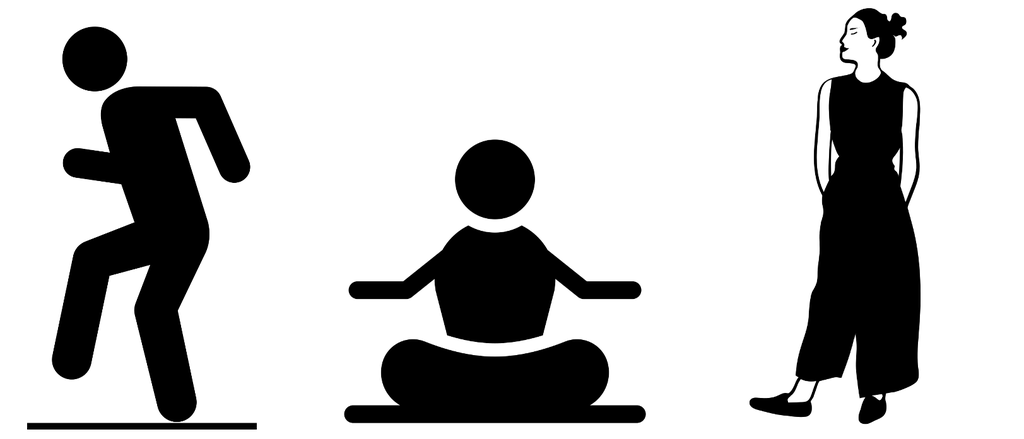

## Neural basis of body perception

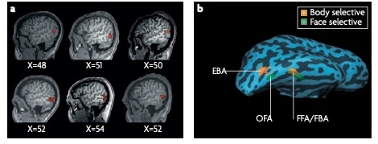

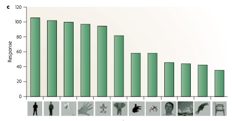

(Peelen & Downing, 2007)

## Bodies in motion

[video not shown]

## Neural basis of bodies in motion

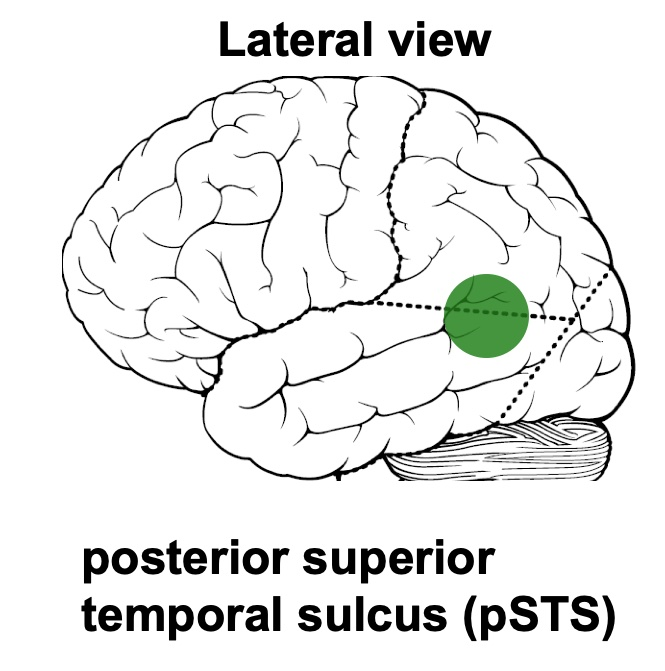

(Grossman et al., 2000; Pitcher & Ungerleider, 2021)

# Joint attention

## Eye gaze

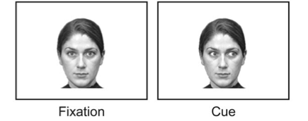

[figure not shown]

[figure not shown]

[figure not shown]

(Frischen et al., 2007)

## Eye gaze in social contexts

[figure not shown]

[Le Tricheur à l’as de carreau by Georges de la Tour (c. 1635)]

## Neural basis of joint attention

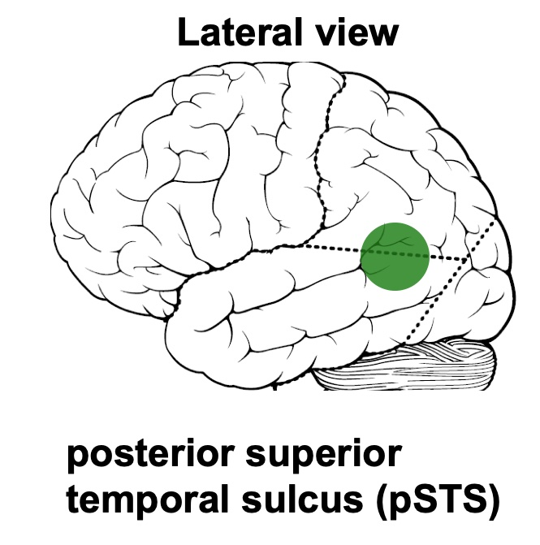

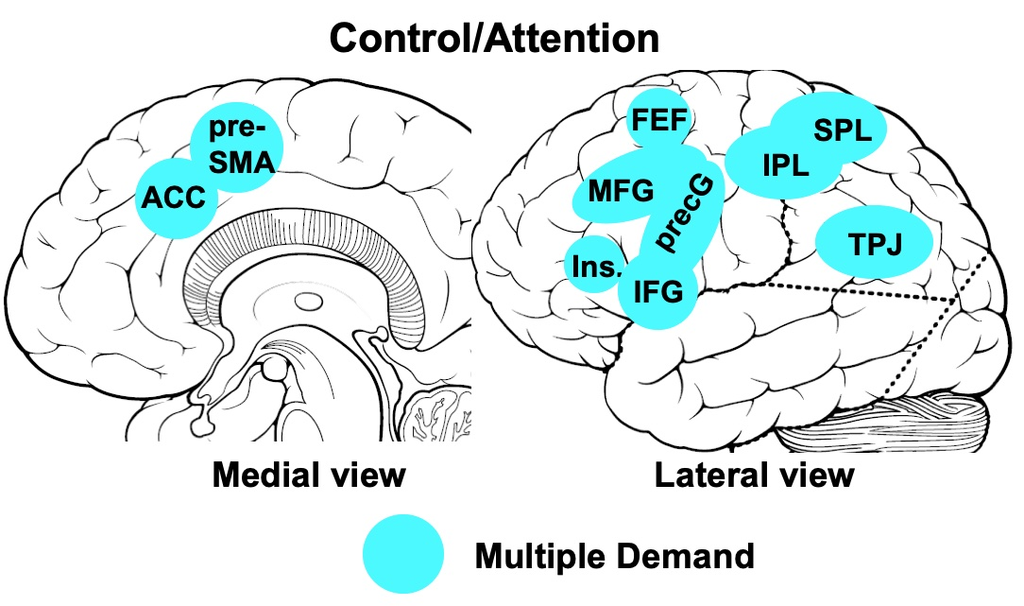

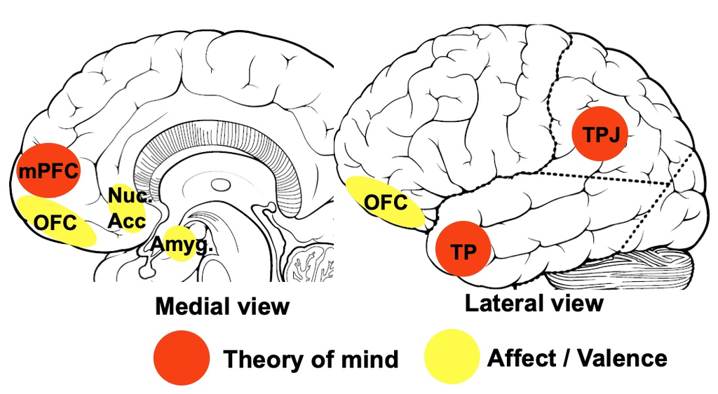

(Hooker et al., 2003; Klein et al., 2009; Redcay & Schilbach, 2019; Shepherd, 2010)

# Trait inferences from faces and bodies

## Trait inferences from faces

Can we infer personality traits from faces?

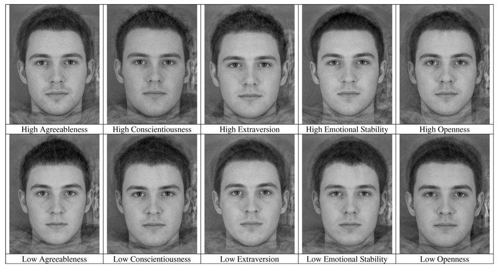

(Penton-Voak et al., 2006; Todorov et al., 2015; Todorov et al., 2025)

## Caution

- ‘A kernal of truth’
- Self-fulfilling prophecies
- Consensus despite a lack of accuracy

(Todorov et al., 2015; Todorov et al., 2025)

## Trait inferences from bodies

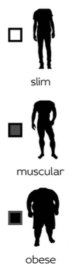

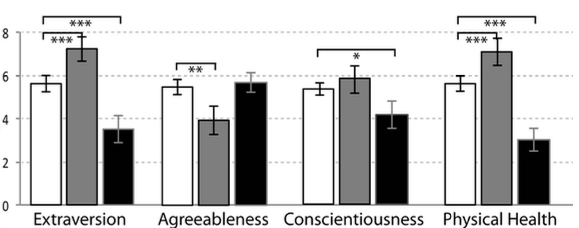

(Greven et al., 2019)

## Trait inferences from bodies: fMRI

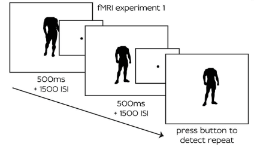

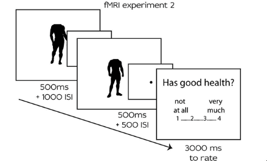

(Greven et al., 2019)

## Trait inferences from bodies: fMRI

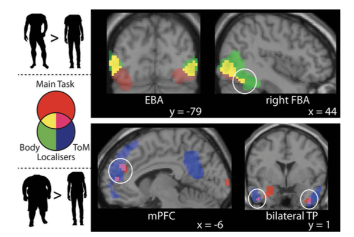

- Muscular > Slim engaged body-selective brain areas
- Heavy > Slim engaged the theory-of-mind network
- Only when an explicit judgment was required (Exp. 2 and not Exp. 1)

(Greven et al., 2019)

# Take a break

# Part 2 - Read and discuss

## Discussion material

- break into small groups (~ 5 per group)
- discuss aspects of the lecture
- discuss aspects of the this article: https://medium.com/@blaisea/physiognomys-new-clothes-f2d4b59fdd6a
- For more details, see also:
- Todorov et al. (2015)
- Chapter 5 from Ward (2022)

## References

Adolphs, R. (2009). The Social Brain: Neural Basis of Social Knowledge. *Annual Review of Psychology*, *60*(1), 693–716. https://doi.org/10.1146/annurev.psych.60.110707.163514

Bruce, V., & Young, A. (1986). Understanding face recognition. *British Journal of Psychology (London, England: 1953)*, *77 ( Pt 3)*, 305–327. https://doi.org/10.1111/j.2044-8295.1986.tb02199.x

Duchaine, B., & Yovel, G. (2015). A Revised Neural Framework for Face Processing. *Annual Review of Vision Science*, *1*, 393–416. https://doi.org/10.1146/annurev-vision-082114-035518

Frischen, A., Bayliss, A. P., & Tipper, S. P. (2007). Gaze cueing of attention: Visual attention, social cognition, and individual differences. *Psychological Bulletin*, *133*(4), 694–724. https://doi.org/10.1037/0033-2909.133.4.694

Greven, I. M., Downing, P. E., & Ramsey, R. (2019). Neural networks supporting social evaluation of bodies based on body shape. *Social Neuroscience*, *14*(3), 328–344. https://doi.org/10.1080/17470919.2018.1448888

Grossman, E., Donnelly, M., Price, R., Pickens, D., Morgan, V., Neighbor, G., & Blake, R. (2000). Brain Areas Involved in Perception of Biological Motion. *Journal of Cognitive Neuroscience*, *12*(5), 711–720. https://doi.org/10.1162/089892900562417

Haxby, J. V., Hoffman, E. A., & Gobbini, M. I. (2000). The distributed human neural system for face perception. *Trends in Cognitive Sciences*, *4*(6), 223–233. http://www.sciencedirect.com/science/article/B6VH9-40CRS36-9/2/25211601271cd66be6930a32cc7af4b1

Hooker, C. I., Paller, K. A., Gitelman, D. R., Parrish, T. B., Mesulam, M. M., & Reber, P. J. (2003). Brain networks for analyzing eye gaze. *Cognitive Brain Research*, *17*(2), 406–418. http://www.sciencedirect.com/science/article/B6SYV-493H3SV-7/2/4e9c65ed3352a98b1b6cde74834f519f

Klein, J. T., Shepherd, S. V., & Platt, M. L. (2009). *Social Attention and the Brain*. *19*(20), R958–R962. http://linkinghub.elsevier.com/retrieve/pii/S0960982209015401

Peelen, M. V., & Downing, P. E. (2007). The neural basis of visual body perception. *Nature Reviews Neuroscience*, *8*(8), 636–648. https://doi.org/10.1038/nrn2195

Penton-Voak, I. S., Pound, N., Little, A. C., & Perrett, D. I. (2006). Personality Judgments from Natural and Composite Facial Images: More Evidence For A “Kernel Of Truth” In Social Perception. *Social Cognition*, *24*(5), 607–640. https://doi.org/10.1521/soco.2006.24.5.607

Pitcher, D., & Ungerleider, L. G. (2021). Evidence for a Third Visual Pathway Specialized for Social Perception. *Trends in Cognitive Sciences*, *25*(2), 100–110. https://doi.org/10.1016/j.tics.2020.11.006

Redcay, E., & Schilbach, L. (2019). Using second-person neuroscience to elucidate the mechanisms of social interaction. *Nature Reviews Neuroscience*, *20*(8), 495–505.

Shepherd, S. V. (2010). Following gaze: Gaze-following behavior as a window into social cognition. *Frontiers in Integrative Neuroscience*, *4*. www.frontiersin.org/neuroscience/integrativeneuroscience/paper/10.3389/fnint.2010.00005/html/

Stanley, D. A., & Adolphs, R. (2013). Toward a Neural Basis for Social Behavior. *Neuron*, *80*(3), 816–826. http://linkinghub.elsevier.com/retrieve/pii/S0896627313009902

Todorov, A., Oh, D., Uddenberg, S., & Albohn, D. N. (2025). Face evaluation: Findings, methods, and challenges. *Annals of the New York Academy of Sciences*, *1545*(1), 28–37. https://doi.org/10.1111/nyas.15293

Todorov, A., Olivola, C. Y., Dotsch, R., & Mende-Siedlecki, P. (2015). Social attributions from faces: Determinants, consequences, accuracy, and functional significance. *Annu Rev Psychol*, *66*, 519–545. https://doi.org/10.1146/annurev-psych-113011-143831

Ward, J. (2022). *The Student’s Guide to Social Neuroscience* (3rd ed.). Psychology Press. https://doi.org/10.4324/9781003057697

## Acknowledgements

- Unless otherwise specified, icons and images were used under license from [The Noun Project](https://thenounproject.com/)
- Slides were created with [Quarto](https://quarto.org/) and [RevealJS](https://revealjs.com/)